# Chargement des librairies et des données

```python
# Import necessary modules and set options
import pandas as pd
import numpy as np
import itertools
import matplotlib.pyplot as plt
import statsmodels.api as sm
from sklearn.linear_model import LinearRegression, RidgeCV, LassoCV, ElasticNetCV, LarsCV, Ridge, lars_path
from sklearn.cross_decomposition import PLSRegression
from sklearn.decomposition import PCA
from sklearn.pipeline import Pipeline
from sklearn.model_selection import GridSearchCV

import warnings
warnings.filterwarnings("ignore")
```

```python
prostate = pd.read_csv('../data/Prostate_Cancer.txt', delimiter=',')
```

```python
prostate.head(10)
```

|  | id | lcavol | lweight | age | lbph | svi | lcp | gleason | pgg45 | lpsa | train |
| --- | --- | --- | --- | --- | --- | --- | --- | --- | --- | --- | --- |
| 0 | 1 | -0.579818 | 2.769459 | 50 | -1.386294 | 0 | -1.386294 | 6 | 0 | -0.430783 | T |
| 1 | 2 | -0.994252 | 3.319626 | 58 | -1.386294 | 0 | -1.386294 | 6 | 0 | -0.162519 | T |
| 2 | 3 | -0.510826 | 2.691243 | 74 | -1.386294 | 0 | -1.386294 | 7 | 20 | -0.162519 | T |
| 3 | 4 | -1.203973 | 3.282789 | 58 | -1.386294 | 0 | -1.386294 | 6 | 0 | -0.162519 | T |
| 4 | 5 | 0.751416 | 3.432373 | 62 | -1.386294 | 0 | -1.386294 | 6 | 0 | 0.371564 | T |
| 5 | 6 | -1.049822 | 3.228826 | 50 | -1.386294 | 0 | -1.386294 | 6 | 0 | 0.765468 | T |
| 6 | 7 | 0.737164 | 3.473518 | 64 | 0.615186 | 0 | -1.386294 | 6 | 0 | 0.765468 | F |
| 7 | 8 | 0.693147 | 3.539509 | 58 | 1.536867 | 0 | -1.386294 | 6 | 0 | 0.854415 | T |
| 8 | 9 | -0.776529 | 3.539509 | 47 | -1.386294 | 0 | -1.386294 | 6 | 0 | 1.047319 | F |
| 9 | 10 | 0.223144 | 3.244544 | 63 | -1.386294 | 0 | -1.386294 | 6 | 0 | 1.047319 | F |

```python
prostate = prostate.drop(['id'], axis=1)
prostate.shape
```

```
(97, 10)
```

## Jeux de données apprentissage et test

```python
# Train-test split
y_train = np.array(prostate[prostate.train == "T"]['lpsa'])
y_test = np.array(prostate[prostate.train == "F"]['lpsa'])
X_train = np.array(prostate[prostate.train == "T"].drop(['lpsa', 'train'], axis=1))
X_test = np.array(prostate[prostate.train == "F"].drop(['lpsa', 'train'], axis=1))
```

# Baseline : régression linéaire classique

```python
linreg_model = LinearRegression(normalize=True).fit(X_train, y_train)
linreg_prediction = linreg_model.predict(X_test)
linreg_mse = np.mean((y_test - linreg_prediction)**2)
linreg_coefs = dict(
    zip(['Intercept'] + prostate.columns.tolist()[:-1],
        np.round(np.concatenate((linreg_model.intercept_, linreg_model.coef_),
        axis=None), 3))
)

print('Linear Regression MSE: {}'.format(np.round(linreg_mse, 3)))
print('Linear Regression coefficients:')
linreg_coefs
```

```
Linear Regression MSE: 0.521
Linear Regression coefficients:
```

```
{'Intercept': 0.429,
 'lcavol': 0.577,
 'lweight': 0.614,
 'age': -0.019,
 'lbph': 0.145,
 'svi': 0.737,
 'lcp': -0.206,
 'gleason': -0.03,
 'pgg45': 0.009}
```

On est habitué à ça

```python
X1_train = sm.add_constant(X_train) # adding a constant
mod = sm.OLS(y_train, X1_train)
res = mod.fit()
print(res.summary())
```

```
                            OLS Regression Results
==============================================================================
Dep. Variable:                      y   R-squared:                       0.694
Model:                            OLS   Adj. R-squared:                  0.652
Method:                 Least Squares   F-statistic:                     16.47
Date:                Thu, 10 Oct 2019   Prob (F-statistic):           2.04e-12
Time:                        08:04:13   Log-Likelihood:                -67.505
No. Observations:                  67   AIC:                             153.0
Df Residuals:                      58   BIC:                             172.9
Df Model:                           8
Covariance Type:            nonrobust
==============================================================================
                 coef    std err          t      P>|t|      [0.025      0.975]
------------------------------------------------------------------------------
const          0.4292      1.554      0.276      0.783      -2.681       3.539
x1             0.5765      0.107      5.366      0.000       0.361       0.792
x2             0.6140      0.223      2.751      0.008       0.167       1.061
x3            -0.0190      0.014     -1.396      0.168      -0.046       0.008
x4             0.1448      0.070      2.056      0.044       0.004       0.286
x5             0.7372      0.299      2.469      0.017       0.140       1.335
x6            -0.2063      0.111     -1.867      0.067      -0.428       0.015
x7            -0.0295      0.201     -0.147      0.884      -0.432       0.373
x8             0.0095      0.005      1.738      0.088      -0.001       0.020
==============================================================================
Omnibus:                        0.825   Durbin-Watson:                   1.690
Prob(Omnibus):                  0.662   Jarque-Bera (JB):                0.389
Skew:                          -0.164   Prob(JB):                        0.823
Kurtosis:                       3.178   Cond. No.                     1.29e+03
==============================================================================

Warnings:
[1] Standard Errors assume that the covariance matrix of the errors is correctly specified.
[2] The condition number is large, 1.29e+03. This might indicate that there are
strong multicollinearity or other numerical problems.
```

# Sous-ensemble optimal

Une approche simple pour choisir un sous-ensemble de variables pour la régression linéaire consiste à essayer toutes les combinaisons possibles et à en choisir une qui minimise un critère certain. C'est ce que vise la recherche du meilleur sous-ensemble de variables pour la régression. Pour chaque $k \in \{1, 2, \ldots, p\}$, où $p$ est le nombre total de variables disponibles, il sélectionne le sous-ensemble de taille $k$ qui donne la plus petite somme résiduelle de carrés. Cependant, la somme des carrés ne peut pas être utilisée comme critère pour déterminer $k$ elle-même, car elle diminue nécessairement avec $k$: plus le nombre de variables incluses dans le modèle est grand, plus ses résidus sont petits. Cela ne garantit toutefois pas de meilleures performances prédictives. C’est pourquoi un autre critère devrait être utilisé pour sélectionner le modèle final. Pour les modèles axés sur la prédiction, une erreur (éventuellement croisée) sur les données de test est un choix courant. Comme la recherche du meilleur sous-ensemble de régression n'est implémentée dans aucun package Python, nous devons effectuer une boucle sur $k$ et tous les sous-ensembles de taille $k$ manuellement. Le bout de code suivant implémente la méthode :

```python
results = pd.DataFrame(columns=['num_features', 'features', 'MSE'])

# Loop over all possible numbers of features to be included
for k in range(1, X_train.shape[1] + 1):
    # Loop over all possible subsets of size k
    for subset in itertools.combinations(range(X_train.shape[1]), k):
        subset = list(subset)
        linreg_model = LinearRegression(normalize=True).fit(X_train[:, subset], y_train)
        linreg_prediction = linreg_model.predict(X_test[:, subset])
        linreg_mse = np.mean((y_test - linreg_prediction)**2)
        results = results.append(pd.DataFrame([{'num_features': k,
                                                'features': subset,
                                                'MSE': linreg_mse}]))

# Inspect best combinations
results = results.sort_values('MSE').reset_index()
print(results.head())

# Fit best model
best_subset_model = LinearRegression(normalize=True).fit(X_train[:, results['features'][0]], y_train)
best_subset_coefs = dict(
    zip(['Intercept'] + prostate.columns.tolist()[:-1],
        np.round(np.concatenate((best_subset_model.intercept_, best_subset_model.coef_), axis=None), 3))
)

print('Best Subset Regression MSE: {}'.format(np.round(results['MSE'][0], 4)))
print('Best Subset Regression coefficients:')
best_subset_coefs
```

```
   index       MSE         features num_features
0      0  0.382801        [0, 4, 6]            3
1      0  0.383256  [0, 1, 2, 4, 6]            5
2      0  0.386119           [0, 4]            2
3      0  0.387086     [0, 2, 4, 6]            4
4      0  0.387742        [0, 4, 7]            3
Best Subset Regression MSE: 0.3828
Best Subset Regression coefficients:
```

```
{'Intercept': 1.274, 'lcavol': 0.595, 'lweight': 0.536, 'age': 0.041}
```

## Régression Ridge

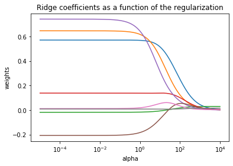

```
Ridge Regression MSE: 0.498
Ridge Regression coefficients:
```

```
{'Intercept': 0.153,
 'lcavol': 0.509,
 'lweight': 0.605,
 'age': -0.016,
 'lbph': 0.14,
 'svi': 0.692,
 'lcp': -0.134,
 'gleason': 0.009,
 'pgg45': 0.007}
```

```python
n_alphas = 400
alphas = np.logspace(-5, 4, n_alphas)
coefs = []
for a in alphas:
    ridge =  Ridge(alpha=a, fit_intercept=False)
    ridge.fit(X_train, y_train)
    coefs.append(ridge.coef_)

# #############################################################################
# Display results
ax = plt.gca()
ax.plot(alphas, coefs)
ax.set_xscale('log')
ax.set_xlim(ax.get_xlim()[::-1])  # reverse axis
plt.xlabel('alpha')
plt.ylabel('weights')
plt.title('Ridge coefficients as a function of the regularization')
plt.axis('tight')
plt.show()

ridge_cv = RidgeCV(normalize=True, alphas=np.logspace(-5, 4, n_alphas), store_cv_values=True)
ridge_model = ridge_cv.fit(X_train, y_train)
ridge_prediction = ridge_model.predict(X_test)
ridge_mse = np.mean((y_test - ridge_prediction)**2)
ridge_coefs = dict(
    zip(['Intercept'] + prostate.columns.tolist()[:-1],
        np.round(np.concatenate((ridge_model.intercept_, ridge_model.coef_),
                                axis=None), 3))
)

print('Ridge Regression MSE: {}'.format(np.round(ridge_mse, 3)))
print('Ridge Regression coefficients:')
ridge_coefs
```

### Erreur évaluée par validation croisée en fonction de $\alpha$

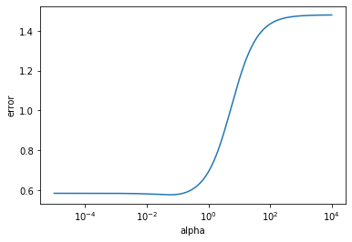

```python
errors = ridge_cv.cv_values_.mean(axis=0)
ax = plt.gca()
ax.plot(alphas, errors)
ax.set_xscale('log')
plt.xlabel('alpha')
plt.ylabel('error')
plt.axis('tight')
plt.show()
```

## Régression Lasso

```
Computing regularization path using the LARS ...
.
```

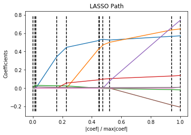

```
LASSO MSE: 0.454
LASSO coefficients:
```

```
{'Intercept': 0.068,
 'lcavol': 0.46,
 'lweight': 0.457,
 'age': -0.0,
 'lbph': 0.051,
 'svi': 0.355,
 'lcp': 0.0,
 'gleason': 0.0,
 'pgg45': 0.002}
```

```python
print("Computing regularization path using the LARS ...")
_, _, coefs = lars_path(X_train, y_train, method='lasso', verbose=True)

xx = np.sum(np.abs(coefs.T), axis=1)
xx /= xx[-1]

plt.plot(xx, coefs.T)
ymin, ymax = plt.ylim()
plt.vlines(xx, ymin, ymax, linestyle='dashed')
plt.xlabel('|coef| / max|coef|')
plt.ylabel('Coefficients')
plt.title('LASSO Path')
plt.axis('tight')
plt.show()

lasso_cv = LassoCV(normalize=True, alphas=np.logspace(-5, 4, n_alphas))
lasso_model = lasso_cv.fit(X_train, y_train)
lasso_prediction = lasso_model.predict(X_test)
lasso_mse = np.mean((y_test - lasso_prediction)**2)
lasso_coefs = dict(
    zip(['Intercept'] + prostate.columns.tolist()[:-1],
        np.round(np.concatenate((lasso_model.intercept_, lasso_model.coef_), axis=None), 3))
)

print('LASSO MSE: {}'.format(np.round(lasso_mse, 3)))
print('LASSO coefficients:')
lasso_coefs
```

Erreur quadratique moyenne calculée par validation croisée en fonction de la valeur de alpha

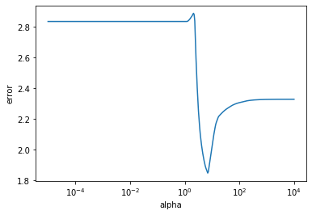

```python
errors = lasso_cv.mse_path_.mean(axis=1)
ax = plt.gca()
ax.plot(alphas, errors)
ax.set_xscale('log')
plt.xlabel('alpha')
plt.ylabel('error')
plt.axis('tight')
plt.show()
```

## Régression Elasticnet

```python
elastic_net_cv = ElasticNetCV(normalize=True, alphas=np.logspace(-5, 4, 400),
                              l1_ratio=np.linspace(0, 1, 100), cv=3)
elastic_net_model = elastic_net_cv.fit(X_train, y_train)
elastic_net_prediction = elastic_net_model.predict(X_test)
elastic_net_mse = np.mean((y_test - elastic_net_prediction)**2)
elastic_net_coefs = dict(
    zip(['Intercept'] + prostate.columns.tolist()[:-1],
        np.round(np.concatenate((elastic_net_model.intercept_,
                                 elastic_net_model.coef_), axis=None), 3))
)

print('Elastic Net MSE: {}'.format(np.round(elastic_net_mse, 3)))
print('Elastic Net coefficients:')
elastic_net_coefs
```

```
Elastic Net MSE: 0.453
Elastic Net coefficients:
```

```
{'Intercept': 0.059,
 'lcavol': 0.46,
 'lweight': 0.459,
 'age': -0.0,
 'lbph': 0.052,
 'svi': 0.359,
 'lcp': 0.0,
 'gleason': 0.0,
 'pgg45': 0.002}
```